# DA 607: NFL Spreads: Populations, Underdogs, and other Factors

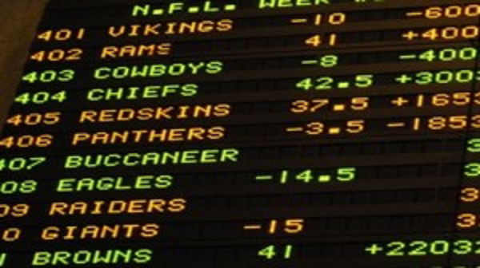

# Introduction

- Vegas bookies create the spreads for NFL Football games.
- They don’t care if the spread is “correct”, they want 50% of betters to choose each team (guaranteeing their “rake”)
- If betters favor certain matchup attributes, perhaps this can be exploited.

# Factors to Analyze

- **Historic NFL Lines:** Does a teams historical performance against the spread create bias on the current spread? Example: How often have they covered in the past?
- **Harris Poll Popularity Rankings:** Does a teams “popularity”, as measured by the Harris Poll, create betting bias?
- **City Populations:** Does the size of the city, and thus their “betting population”, create bias in the spreads?
- **Game Location:** How often does the Home team cover the spread?
- **Points Scored:** Does “how much they covered by” history affect the teams current spreads?
- **Stadium Attendance:** Does the teams stadium attendance (percent of stadium capacity filled) show a betting bias that can be exploited?

# ESEMN Workflow

## Obtain + Scrub form the following 3 Data Sources

### Source 1: Historic NFL Lines

Download the Historic NFL Lines CSVs from web to disk:

https://github.com/mattrjacobs/nflspread/tree/master/files

```r
# dont want to keep downloading from web each time:

url_prefix <- 'https://raw.githubusercontent.com/mattrjacobs/nflspread/master/files/nfl'

if(DO_DOWNLOAD_FILES){
  for(i in 1979:2013)
  {
    input_url <- paste(url_prefix,i,"lines.csv", sep="")
    output_file <- paste("lines/nfl",i,"lines.csv", sep="")
    download.file(input_url, destfile=output_file)
  }
}
```

### Source 2: Harris Poll - Scrape for Year-over-Year Team Rankings

This includes the “one data transformation operation”, removing all equal (=) signs from the rankings table.

```r
if(DO_HARRIS_POLL_FAVS){
 harris_tables <- readHTMLTable(HARRIS_POLL_URL, header = TRUE)
  harris_df <- harris_tables[[3]]
  colnames(harris_df)[1] <- "team"
  # some had = sign before numbers, got it out...
  harris_df <- as.data.frame(sapply(harris_df,gsub,pattern="=",replacement=""))
  numeric_cols <- c(2:ncol(harris_df))
  harris_df[, numeric_cols] <- sapply(harris_df[, numeric_cols], as.numeric)
  harris_df$MEAN_RANK <- rowMeans(subset(harris_df, select = numeric_cols), na.rm = TRUE)
  harris_sub <- c(ncol((harris_df)-5):(ncol(harris_df)-1))
  harris_df$MEAN_RANK_5 <- rowMeans(subset(harris_df, select = harris_sub), na.rm = TRUE)
  kable(head(harris_df[,-c(4:12)]))
}
```

| team | 1998 | 1999 | 2011 | 2013 | 2014 | 2015 | MEAN_RANK | MEAN_RANK_5 |
| --- | --- | --- | --- | --- | --- | --- | --- | --- |
| Dallas Cowboys | 1 | 1 | 1 | 1 | 22 | 1 | 5.666667 | 3.333333 |
| Green Bay Packers | 12 | 19 | 20 | 10 | 19 | 11 | 14.066667 | 12.533333 |
| New England Patriots | 8 | 3 | 24 | 26 | 26 | 11 | 18.800000 | 14.900000 |
| Denver Broncos | 23 | 22 | 8 | 21 | 1 | 23 | 12.600000 | 17.800000 |
| Pittsburgh Steelers | 24 | 23 | 10 | 28 | 23 | 24 | 17.333333 | 20.666667 |
| Seattle Seahawks | 13 | 7 | 18 | 4 | 24 | 25 | 11.866667 | 18.433333 |

See above for MEAN of rankings, and below for graphcs of team’s mean ranks.

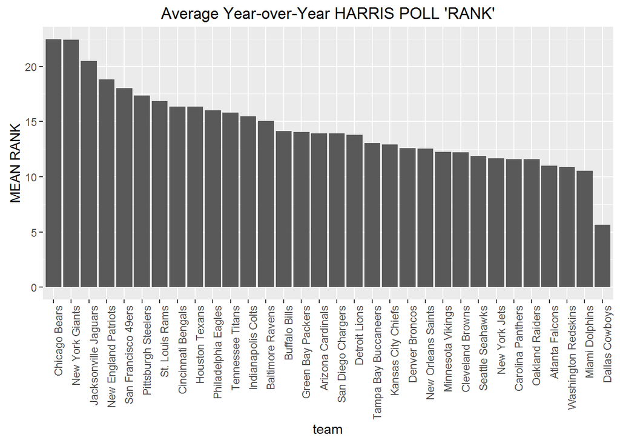

```r
the_aes <- aes(x=reorder(team,-MEAN_RANK), y=MEAN_RANK)
plt <- ggplot(harris_df, the_aes) + geom_bar(stat="identity")
plt <- plt + ggtitle("Average Year-over-Year HARRIS POLL 'RANK'") + labs(x="team", y="MEAN RANK")
plt <- plt + stat_summary(fun.y=sum, geom="bar")
plt <- plt + theme(axis.text.x = element_text(angle = 90, hjust = 1))
show(plt)
```

### Source 3: City Populations

Data was copy-pasted from the following Wikipedia Link:

https://en.wikipedia.org/wiki/List_of_United_States_cities_by_population

and in the following manner:

```r
do_explicit_populations <- function(df){

  df[, "pop"] <- 0

  df[df$team == "New York Giants", "pop"] <- 8491079
  df[df$team == "Green Bay Packers", "pop"] <- 104891

  # same for the rest of the teams....not showing here (too many lines...)
}
```

| team | pop |
| --- | --- |
| Dallas Cowboys | 1281047 |
| Green Bay Packers | 104891 |
| New England Patriots | 655884 |
| Denver Broncos | 663862 |
| Pittsburgh Steelers | 305412 |
| Seattle Seahawks | 668342 |

# Work

In these steps, just gathering the data and raw calculations, will do analysis in “Conclusions”)

### Work 1: Load the downloaded CSVs of historical games into a Data Frame.

DataFrame created: “lines_df”"

```r
lines_df <- read.csv(paste("lines/nfl",1978,"lines.csv", sep=""))
lines_df['season'] <- 1978
for(i in 1979:2013)
{
  filepath <- paste("lines/nfl",i,"lines.csv", sep="")
  #print(filepath)
  lines_df_new <- read.csv(filepath)
  lines_df_new['season'] <- i
  lines_df <- rbind(lines_df, lines_df_new)
}

colnames(lines_df) <- c("date","v_team","v_score","h_team","h_score","line","total", "season")
```

### Work 2: New Field: “h_covered”: Did the HOME team “cover”?

DataFrame updated: “lines_df”"

```r
lines_df$h_covered <- ((lines_df$v_score + lines_df$line) > lines_df$h_score)
kable(head(lines_df))
```

| date | v_team | v_score | h_team | h_score | line | total | season | h_covered |
| --- | --- | --- | --- | --- | --- | --- | --- | --- |
| 09/01/1979 | Detroit Lions | 16 | Tampa Bay Buccaneers | 31 | 3 | 30.0 | 1978 | FALSE |
| 09/02/1979 | Atlanta Falcons | 40 | New Orleans Saints | 34 | 5 | 32.0 | 1978 | TRUE |
| 09/02/1979 | Baltimore Colts | 0 | Kansas City Chiefs | 14 | 1 | 37.0 | 1978 | FALSE |
| 09/02/1979 | Cincinnati Bengals | 0 | Denver Broncos | 10 | 3 | 31.5 | 1978 | FALSE |
| 09/02/1979 | Cleveland Browns | 25 | New York Jets | 22 | 2 | 41.0 | 1978 | TRUE |
| 09/02/1979 | Dallas Cowboys | 22 | St Louis Cardinals | 21 | -4 | 37.0 | 1978 | FALSE |

```r
# Just confirming the rowcounts are good...winners + losers == rowcount
lines_df_home_covered <- sum(lines_df$h_covered==TRUE)
lines_df_home_didnt_cover <- sum(lines_df$h_covered==FALSE)

# confirm it adds up to total number of rows:
sum(lines_df_home_covered, lines_df_home_didnt_cover) == nrow(lines_df)
```

```
## [1] TRUE
```

### Work 3: Choose 2013 Season to Analyze

Subset the spreads data, only take 2013 (the most recent):

DataFrame updated: “lines_df”"

```r
lines_df <- lines_df[lines_df$season == 2013,]
kable(head(lines_df))
```

|  | date | v_team | v_score | h_team | h_score | line | total | season | h_covered |
| --- | --- | --- | --- | --- | --- | --- | --- | --- | --- |
| 8175 | 09/05/2013 | Baltimore Ravens | 27 | Denver Broncos | 49 | 7.5 | 49.5 | 2013 | FALSE |
| 8176 | 09/08/2013 | New England Patriots | 23 | Buffalo Bills | 21 | -10.5 | 51.5 | 2013 | FALSE |
| 8177 | 09/08/2013 | Tennessee Titans | 16 | Pittsburgh Steelers | 9 | 6.0 | 42.0 | 2013 | TRUE |
| 8178 | 09/08/2013 | Atlanta Falcons | 17 | New Orleans Saints | 23 | 3.5 | 56.0 | 2013 | FALSE |
| 8179 | 09/08/2013 | Tampa Bay Buccaneers | 17 | New York Jets | 18 | -6.0 | 39.0 | 2013 | FALSE |
| 8180 | 09/08/2013 | Kansas City Chiefs | 28 | Jacksonville Jaguars | 2 | -4.5 | 43.0 | 2013 | TRUE |

### Work 4: Create ‘Winner Points’ Data Subset:

DataFrame created: “covered_by_summary_df”

How much did you score when you won?

Its a union of home_points when home_covered and away_points when not(home_covered)

Therefore, your times covered matter (because you only get the points if you covered) and the total points matter (because we’re summing up the points on the days that you covered)

```r
covered_by_summary_home_away <- sqldf("select h_team as team, sum(h_score) as winner_points from lines_df where h_covered group by team union select v_team as team, sum(v_score) as winner_points from lines_df where not(h_covered) group by team ", stringsAsFactors = FALSE)

covered_by_summary_df <- sqldf("select team, sum(winner_points) as winner_points from covered_by_summary_home_away group by team order by winner_points desc", stringsAsFactors = FALSE)
kable(head(covered_by_summary_df))
```

| team | winner_points |
| --- | --- |
| Chicago Bears | 271 |
| Green Bay Packers | 212 |
| Denver Broncos | 207 |
| Detroit Lions | 202 |
| Houston Texans | 195 |
| Washington Redskins | 186 |

### Work 6: Merge the h_score and v_score logic (turn into times covered)

DataFrame created: “times_covered_df”

Subset the spreads data, only take 2013 (the most recent):

```r
covered_count_home_away <- sqldf("select h_team as team, count(*) as times_covered from lines_df where h_covered group by team union select v_team as team, count(*) as times_covered from lines_df where not(h_covered) group by team ", stringsAsFactors = FALSE)

times_covered_df <- sqldf("select team, sum(times_covered) as times_covered from covered_count_home_away group by team order by times_covered desc", stringsAsFactors = FALSE)

kable(head(times_covered_df[,]))
```

| team | times_covered |
| --- | --- |
| Houston Texans | 12 |
| Chicago Bears | 11 |
| Washington Redskins | 11 |
| Jacksonville Jaguars | 10 |
| Tampa Bay Buccaneers | 10 |
| Atlanta Falcons | 9 |

### Work 7: Stadium Attendance

```r
attendance_df <- read.csv("Stadium_Attendance.csv")
kable(head(attendance_df))
```

| team | Stadium | Home.games | Average.attendance | Total.attendance | Capacity.percentage |
| --- | --- | --- | --- | --- | --- |
| Green Bay Packers | Lambeau Field | 8 | 78413 | 627308 | 107.2 |
| Indianapolis Colts | Lucas Oil Stadium | 8 | 66047 | 528381 | 104.8 |
| San Francisco 49ers | Levi’s Stadium | 8 | 70799 | 566392 | 103.4 |
| Seattle Seahawks | CenturyLink Field | 8 | 69020 | 552162 | 103.0 |
| Miami Dolphins | Sun Life Stadium | 8 | 67193 | 537548 | 102.9 |
| Philadelphia Eagles | Lincoln Financial Field | 8 | 69483 | 555868 | 102.8 |

### Work 8: Populations (and start the merge…)

```r
final_df <- do_explicit_populations(covered_by_summary_df)
kable(head(final_df))
```

| team | winner_points | pop |
| --- | --- | --- |
| Chicago Bears | 271 | 2722389 |
| Green Bay Packers | 212 | 104891 |
| Denver Broncos | 207 | 663862 |
| Detroit Lions | 202 | 680250 |
| Houston Texans | 195 | 2239558 |
| Washington Redskins | 186 | 658893 |

### Work (FINAL MERGE): All into single data frame for Analysis:

```r
harris_to_merge <- harris_df[ , which(names(harris_df) %in% c("team","MEAN_RANK","MEAN_RANK_5"))]
final_df <- merge(final_df,times_covered_df,by="team")
final_df <- merge(final_df,harris_to_merge,by="team")
attendance_df_to_merge <- attendance_df[ , which(names(attendance_df) %in% c("team","Capacity.percentage"))]
final_df <- merge(final_df,attendance_df_to_merge,by="team")

kable(head(final_df))
```

| team | winner_points | pop | times_covered | MEAN_RANK | MEAN_RANK_5 | Capacity.percentage |
| --- | --- | --- | --- | --- | --- | --- |
| Arizona Cardinals | 133 | 1537058 | 3 | 13.93333 | 8.466667 | 98.7 |
| Atlanta Falcons | 179 | 456002 | 9 | 11.00000 | 7.500000 | 98.8 |
| Baltimore Ravens | 156 | 622793 | 8 | 15.06667 | 14.033333 | 100.0 |
| Buffalo Bills | 141 | 258703 | 8 | 14.13333 | 12.066667 | 95.6 |
| Carolina Panthers | 90 | 809958 | 6 | 11.60000 | 9.800000 | 100.4 |
| Chicago Bears | 271 | 2722389 | 11 | 22.46667 | 24.233333 | 100.9 |

# The Calculations

```r
# final_df$team +
final_lm <- lm(final_df$times_covered ~ final_df$winner_points + final_df$pop + final_df$MEAN_RANK + final_df$MEAN_RANK_5 + final_df$Capacity.percentage)

summary(final_lm)
```

```
##
## Call:
## lm(formula = final_df$times_covered ~ final_df$winner_points +
##     final_df$pop + final_df$MEAN_RANK + final_df$MEAN_RANK_5 +
##     final_df$Capacity.percentage)
##
## Residuals:
##     Min      1Q  Median      3Q     Max
## -4.8586 -0.9031  0.1352  1.0053  4.0644
##
## Coefficients:
##                                Estimate Std. Error t value Pr(>|t|)
## (Intercept)                   1.629e+01  7.329e+00   2.223   0.0355 *
## final_df$winner_points        1.294e-02  8.735e-03   1.482   0.1509
## final_df$pop                  1.605e-07  1.977e-07   0.812   0.4247
## final_df$MEAN_RANK            4.140e-01  1.792e-01   2.311   0.0294 *
## final_df$MEAN_RANK_5         -2.078e-01  1.200e-01  -1.731   0.0957 .
## final_df$Capacity.percentage -1.460e-01  7.569e-02  -1.929   0.0652 .
## ---
## Signif. codes:  0 '***' 0.001 '**' 0.01 '*' 0.05 '.' 0.1 ' ' 1
##
## Residual standard error: 2.037 on 25 degrees of freedom
## Multiple R-squared:  0.3468, Adjusted R-squared:  0.2162
## F-statistic: 2.655 on 5 and 25 DF,  p-value: 0.04664
```

```r
times_covered_ig <- information.gain(times_covered~., final_df)

print(times_covered_ig)
```

```
##                     attr_importance
## team                        1.60742
## winner_points               0.00000
## pop                         0.00000
## MEAN_RANK                   0.00000
## MEAN_RANK_5                 0.00000
## Capacity.percentage         0.00000
```

# Conclusions

There are flaws in the logic here:

- The spreads Data is from 2013 while the “favorites”" data 2015
- Picked random number of years for Harris Poll averages (ie 5 and ALL for which years to summarize)
- Not looking at many other factors, such as win streaks, player statistics, etc.
- Some stats are slightly circular: The team ranks may be determined by how often they cover

It would be quite interesting to look at statistics more historically to see if there was a point and time in which these predictions would have been more possible, when all of the indicators were not already in use to create the lines.